# R Tidyverse notes

This is an [R Markdown] Notebook for help with tidyverse.

First set up the directory and load the libraries needed.

```r
setwd("~/R/tidyverse")
library(tidyverse)
#library()
```

# Graph plotting

## Scatterplots

The examples use the dataframe mpg (sometimes mtcars?). The basic template is:

ggplot(data = <DATA>) +  
<GEOM_FUNCTION>(mapping = aes(<MAPPINGS>))

```r
ggplot(data = mpg) +
  geom_point(mapping = aes(x = displ, y = hwy),
#  position = "jitter"
  )
```

Colouring by class:

```r
ggplot(data = mpg) +
  geom_point(mapping = aes(x = displ, y = hwy, colour = class))
```

Aesthetics other than colour are: size, alpha (transparency), shape, …

Placing colour outside aes() gives a different result (only changes the appearance).

```r
ggplot(data = mpg) +
  geom_point(mapping = aes(x = displ, y = hwy), colour = "blue")
```

One can also map a continuous (rather than categorical) variable to colour, alpha, size, but not to shape. (Note these are all different “aesthetics”.)

An interesting variation is to map colour to a logical variable:

```r
ggplot(data = mpg) +
  geom_point(mapping = aes(x = displ, y = hwy, colour = displ < 5))
```

We can also add facets.

```r
ggplot(data = mpg) +
  geom_point(mapping = aes(x = displ, y = hwy)) +
  facet_wrap( ~ class, nrow = 2)
```

One can also facet the plot on the combination of two variables by using facet_grid:

```r
ggplot(data = mpg) +
  geom_point(mapping = aes(x = displ, y = hwy)) +
  facet_grid(drv ~ cyl)
```

Here is a different geom, a smooth line instead of points:

```r
ggplot(data = mpg) +
  geom_smooth(mapping = aes(x = displ, y = hwy))
```

One can also split the line plot by type of drive:

```r
ggplot(data = mpg) +
  geom_smooth(mapping = aes(x = displ, y = hwy, linetype = drv))
```

One can also overlay layers:

```r
ggplot(data = mpg) +
  geom_smooth(mapping = aes(x = displ, y = hwy)) +
  geom_point(mapping = aes(x = displ, y = hwy))
```

An alternative and better way of doing this would avoid the repeated mapping definition. Note that colour is mapped to class only in the local geom_point layer.

```r
ggplot(data = mpg, mapping = aes(x = displ, y = hwy)) +
  geom_smooth() +
  geom_point(mapping = aes(colour = class))
```

Check this (either smooth or point produces a legend, suppress both for no legend):

```r
ggplot(data = mpg, mapping = aes(x = displ, y = hwy, colour = drv)) +
  geom_smooth(show.legend = FALSE) +
  geom_point(show.legend = FALSE)
```

You can also filter the data made by one of the geoms (Note that se = FALSE removes the confidence band):

```r
ggplot(data = mpg, mapping = aes(x = displ, y = hwy)) +
  geom_smooth(data = filter(mpg, class == "subcompact"), se = FALSE) +
  geom_point(mapping = aes(colour = class), show.legend = FALSE)
```

## Bar charts

Bar charts are used to show frequencies by various groupings. The examples below use the diamonds dataset, which contains information about ~54k diamonds including the price, carat, colour, clarity, cut, depth z (percentage relative to mean of length x and width y) and table (percentage relative to width) of each diamond.

Graphs like scatterplot plot the raw values taken from the dataset. However, bar charts, histograms, frequency polygons do more: they bin the data and find counts before plotting. Smoothers fit a model to the data and plot predictions from the model. Boxplots compute a summary and display this through a box.

```r
ggplot(data = diamonds) +
  geom_bar(mapping = aes(x = cut))
```

Note that the same chart can be created with stat_count instead of geom_bar:

```r
ggplot(data = diamonds) +
  stat_count(mapping = aes(x = cut))
```

Note that every geom has a default stat and every stat has a default geom. (See the cheatsheet for different stats.) We can suppress stat_count when calling geom_bar by including stat = “identity” as a parameter spec.

&& More on this later &&

We can also produce a bar chart of proportion:

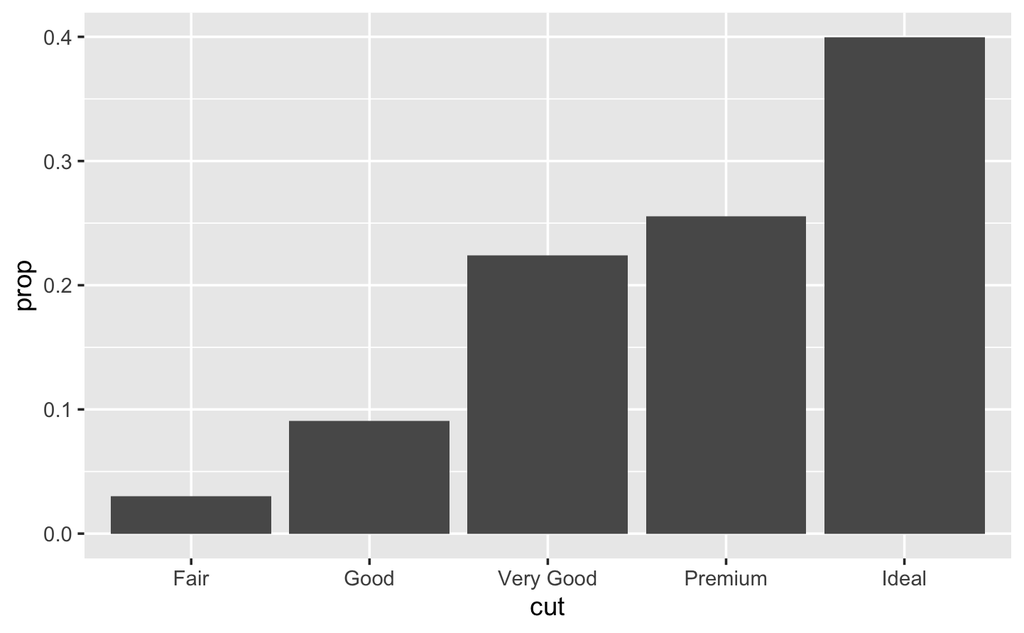

```r
ggplot(data = diamonds) +
  geom_bar(
    mapping = aes(x = cut, y = ..prop.., group = 1)
  )
```

Here is a chart produced by stat_summary, which gives the range of depth values grouped by cut:

```r
ggplot(data = diamonds) +
  stat_summary(
   mapping = aes(x = cut, y = depth),
   fun.min = min,
   fun.max = max,
   fun = median
  )
```

Some fun decorations:

```r
ggplot(data = diamonds) +
  geom_bar(mapping = aes(x = cut, fill = cut))
```

For a stacked bar, code a different variable with fill:

```r
ggplot(data = diamonds) +
  geom_bar(mapping = aes(x = cut, fill = clarity))
```

We can adjust how the bars are positioned using three values for the position parameter: “identity”, “dodge” and “fill”.

```r
ggplot(data = diamonds) +
  geom_bar(
    mapping = aes(x = cut, fill = clarity),
    position = "dodge"
  )
```

When position = “fill”, it produces equal sized bars – easier for comparison.

```r
ggplot(data = diamonds) +
  geom_bar(
    mapping = aes(x = cut, fill = clarity),
    position = "fill"
  )
```

When position = “identity”, the bars overlap, which is awkward. So we need to do extra stuff by making the bars slightly (alpha = 0.2) or fully (fill = NA) transparent:

```r
ggplot(
  data = diamonds,
  mapping = aes(x = cut, fill = clarity)
) +
#  geom_bar(fill = NA, position = "identity")
  geom_bar(alpha = 0.2, position = "identity")
```

## Coordinate systems

These are “probably the most complicated part of ggplot2”.

Flipping x and y axes.

```r
ggplot(data = mpg, mapping = aes(x = class, y = hwy)) +
  geom_boxplot() #+ coord_flip()
```

Plotting maps with correct aspect ratio:

```r
nz <- map_data("nz")
ggplot(nz, aes(long, lat, group = group)) +
  geom_polygon(fill = "white", colour = "black")
ggplot(nz, aes(long, lat, group = group)) +
  geom_polygon(fill = "white", colour = "black") + coord_quickmap()
```

Plotting with polar coordinates:

```r
bar <- ggplot(data = diamonds) +
  geom_bar(
    mapping = aes(x = cut, fill = cut),
    show.legend = FALSE,
    width = 1
  ) +
  theme(aspect.ratio = 1) +
  labs(x = NULL, y = NULL)

bar + coord_flip()
bar + coord_polar()
```

# Transforming data

The package that is used to transform data is dplyr.

Common variable types: int, dbl, chr, dttm, lgl, fctr, date.

Five key dplyr functions: filter(), arrange(), select(), mutate(), summarize(). All of these take a data frame as the first argument, and output a new data frame.

A function with changes the scope of the above functions: group_by().

## Filtering rows

Filter selects observations. (Note that wrapping assignment in parantheses also prints out the output.)

```r
(jan1 <- filter(flights, month == 1, day == 1))
#nov_dec <- filter(flights, month %in% c(11, 12))
(nov_dec <- filter(flights, month == 11 | month == 12))
```

Some flights have a missing dep_time. Let’s filter them.

```r
(missing_dep_time <- filter(flights, is.na(dep_time)))
```

## Adding new variables

The function that does this is mutate(). Note that you can immediately use the new variables.

```r
flights_sml <- select(flights,
  year:day,
  ends_with("delay"),
  distance,
  air_time
)
mutate(flights_sml,
  gain = arr_delay - dep_delay,
  speed = distance / air_time * 60,
  hours = air_time / 60,
  gain_per_hour = gain / hours
)
```